# Netflix - Data Exploration and Visualisation

## Suman Debnath

[figure not shown]

# Introduction

Netflix is one of the most popular media and video streaming platforms. They have over 10000 movies or tv shows available on their platform, as of mid-2021, they have over 222M Subscribers globally. This tabular dataset consists of listings of all the movies and tv shows available on Netflix, along with details such as - cast, directors, ratings, release year, duration, etc.

**Business Problem**

Analyze the data and generate insights that could help Netflix ijn deciding which type of shows/movies to produce and how they can grow the business in different countries

**Dataset**

Link: [Dataset_link](https://d2beiqkhq929f0.cloudfront.net/public_assets/assets/000/000/940/original/netflix.csv)

The dataset provided to you consists of a list of all the TV shows/movies available on Netflix:

`Show_id`: Unique ID for every Movie / Tv Show

`Type`: Identifier - A Movie or TV Show

`Title`: Title of the Movie / Tv Show

`Director`: Director of the Movie

`Cast`: Actors involved in the movie/show

`Country`: Country where the movie/show was produced

`Date_added`: Date it was added on Netflix

`Release_year`: Actual Release year of the movie/show

`Rating`: TV Rating of the movie/show

`Duration`: Total Duration - in minutes or number of seasons

`Listed_in`: Genre

`Description`: The summary description

# Summary

- Netflix added more movies as compare to TV shows, as the data shows almost 70% of the content are of type Movies
- Content for United States on Netflix is maximum followed by India and UK, as compare to other countries.
- Netflix content is mostly available for Mature Audience [Only for Adults]
- Very less no. of TV shows which are meant for Children
- Most popular genres in recent years are International movies, Dramas, Comedies, and International TV Shows
- In 2020, there is significant amount of drop in content added due to COVID pandemic

For **`Movies`**

- In United States , India and United kingdom movies are more popular as comapre to other countires
- Almost same no. of movies are added on netflix every month.
- Most the movies are around the duration of 1h 30mins

For **`TV Shows`**

- Most of the TV shows have 1 season or 2 seasons.
- For Japan and South Korea, Netflix should focus more on TV shows as compare to movies

# Recommendation

For **`Movies`**

- Preferred movies duration should be less than 2hrs or so.
- Netflix should add more movies for United States and India falling in category of International movies and comedies
- Netflix should add more movies for United States and India having rating of TV-MA & TV-14.
- Top three countries where movies added are United States, India & United Kingdom.
- Netflix should add Movies/TV Show on Friday than any other weekday.

## Importing all the `libs`

```python
import pandas as pd
import numpy as np
import matplotlib.pyplot as plt
import seaborn as sns
```

## Loading the `data`

```python
# data_set = 'https://d2beiqkhq929f0.cloudfront.net/public_assets/assets/000/000/940/original/netflix.csv'
data_set = 'netflix.csv'
```

```python
df = pd.read_csv(data_set)
```

```python
df.shape
```

```
(8807, 12)
```

```python
df.info()
```

```
<class 'pandas.core.frame.DataFrame'>
RangeIndex: 8807 entries, 0 to 8806
Data columns (total 12 columns):
 #   Column        Non-Null Count  Dtype
---  ------        --------------  -----
 0   show_id       8807 non-null   object
 1   type          8807 non-null   object
 2   title         8807 non-null   object
 3   director      6173 non-null   object
 4   cast          7982 non-null   object
 5   country       7976 non-null   object
 6   date_added    8797 non-null   object
 7   release_year  8807 non-null   int64
 8   rating        8803 non-null   object
 9   duration      8804 non-null   object
 10  listed_in     8807 non-null   object
 11  description   8807 non-null   object
dtypes: int64(1), object(11)
memory usage: 825.8+ KB
```

```python
df.sample(5)
```

|  | show_id | type | title | director | cast | country | date_added | release_year | rating | duration | listed_in | description |
| --- | --- | --- | --- | --- | --- | --- | --- | --- | --- | --- | --- | --- |
| 323 | s324 | TV Show | 30 Rock | NaN | Tina Fey, Alec Baldwin, Tracy Morgan, Jane Kra... | United States | August 1, 2021 | 2012 | TV-14 | 7 Seasons | TV Comedies | Liz Lemon juggles the demands of running an NB... |
| 4967 | s4968 | TV Show | Trump: An American Dream | NaN | Donald Trump | United Kingdom | March 30, 2018 | 2018 | TV-14 | 1 Season | Docuseries | Friends, associates and critics reveal the tru... |
| 7979 | s7980 | Movie | Secrets of Westminster | Louise Wardle | Samuel West | United States, United Kingdom | April 22, 2017 | 2014 | TV-PG | 55 min | Documentaries, International Movies | Take an insider's tour of Parliament, Big Ben ... |
| 8486 | s8487 | Movie | The Ring | Gore Verbinski | Naomi Watts, Martin Henderson, David Dorfman, ... | United States | January 1, 2020 | 2002 | PG-13 | 116 min | Horror Movies, Thrillers | A reporter watches a video that supposedly set... |
| 507 | s508 | Movie | Three Thieves | Udoka Oyeka | Koye Kekere Ekun, Shawn Faqua, Frank Donga, Lu... | NaN | July 7, 2021 | 2019 | TV-14 | 108 min | Comedies, International Movies | Frustrated at work, three young men use a case... |

## Observation

In this data set we can see the follow which we need to take care before we do anything

> The following column contains the data seperated by comma (,) so we need to separate it out: `cast`, `director`, `country`, `listed_in`

> We have many `NaN` (missing value) in many fields, like `director`, `cast`, `country`

> The column `date_added` is a string, we may like to change it to date format

> The column `duration` is mixed, like in mins for Movie and no. of seasons for TV Show

## Exploring the data

```python
df.describe()
```

|  | release_year |
| --- | --- |
| count | 8807.000000 |
| mean | 2014.180198 |
| std | 8.819312 |
| min | 1925.000000 |
| 25% | 2013.000000 |
| 50% | 2017.000000 |
| 75% | 2019.000000 |
| max | 2021.000000 |

```python
df.info()
```

```
<class 'pandas.core.frame.DataFrame'>
RangeIndex: 8807 entries, 0 to 8806
Data columns (total 12 columns):
 #   Column        Non-Null Count  Dtype
---  ------        --------------  -----
 0   show_id       8807 non-null   object
 1   type          8807 non-null   object
 2   title         8807 non-null   object
 3   director      6173 non-null   object
 4   cast          7982 non-null   object
 5   country       7976 non-null   object
 6   date_added    8797 non-null   object
 7   release_year  8807 non-null   int64
 8   rating        8803 non-null   object
 9   duration      8804 non-null   object
 10  listed_in     8807 non-null   object
 11  description   8807 non-null   object
dtypes: int64(1), object(11)
memory usage: 825.8+ KB
```

```python
df.describe(include='object').T
```

|  | count | unique | top | freq |
| --- | --- | --- | --- | --- |
| show_id | 8807 | 8807 | s1 | 1 |
| type | 8807 | 2 | Movie | 6131 |
| title | 8807 | 8807 | Dick Johnson Is Dead | 1 |
| director | 6173 | 4528 | Rajiv Chilaka | 19 |
| cast | 7982 | 7692 | David Attenborough | 19 |
| country | 7976 | 748 | United States | 2818 |
| date_added | 8797 | 1767 | January 1, 2020 | 109 |
| rating | 8803 | 17 | TV-MA | 3207 |
| duration | 8804 | 220 | 1 Season | 1793 |
| listed_in | 8807 | 514 | Dramas, International Movies | 362 |
| description | 8807 | 8775 | Paranormal activity at a lush, abandoned prope... | 4 |

```python
df.isnull().sum()
```

```
show_id            0
type               0
title              0
director        2634
cast             825
country          831
date_added        10
release_year       0
rating             4
duration           3
listed_in          0
description        0
dtype: int64
```

```python
# Percentage of null value in each columns
(df.isnull().sum() / df.shape[0]) * 100
```

```
show_id          0.000000
type             0.000000
title            0.000000
director        29.908028
cast             9.367549
country          9.435676
date_added       0.113546
release_year     0.000000
rating           0.045418
duration         0.034064
listed_in        0.000000
description      0.000000
dtype: float64
```

```python
df.columns
```

```
Index(['show_id', 'type', 'title', 'director', 'cast', 'country', 'date_added',
       'release_year', 'rating', 'duration', 'listed_in', 'description'],
      dtype='object')
```

```python
df.nunique()
```

```
show_id         8807
type               2
title           8807
director        4528
cast            7692
country          748
date_added      1767
release_year      74
rating            17
duration         220
listed_in        514
description     8775
dtype: int64
```

```python
df.shape
```

```
(8807, 12)
```

## Unnesting the data for few of the cols (`cast`, `director`, `country`, `listed_in`)

```python
df.head(4)
```

|  | show_id | type | title | director | cast | country | date_added | release_year | rating | duration | listed_in | description |
| --- | --- | --- | --- | --- | --- | --- | --- | --- | --- | --- | --- | --- |
| 0 | s1 | Movie | Dick Johnson Is Dead | Kirsten Johnson | NaN | United States | September 25, 2021 | 2020 | PG-13 | 90 min | Documentaries | As her father nears the end of his life, filmm... |
| 1 | s2 | TV Show | Blood & Water | NaN | Ama Qamata, Khosi Ngema, Gail Mabalane, Thaban... | South Africa | September 24, 2021 | 2021 | TV-MA | 2 Seasons | International TV Shows, TV Dramas, TV Mysteries | After crossing paths at a party, a Cape Town t... |
| 2 | s3 | TV Show | Ganglands | Julien Leclercq | Sami Bouajila, Tracy Gotoas, Samuel Jouy, Nabi... | NaN | September 24, 2021 | 2021 | TV-MA | 1 Season | Crime TV Shows, International TV Shows, TV Act... | To protect his family from a powerful drug lor... |
| 3 | s4 | TV Show | Jailbirds New Orleans | NaN | NaN | NaN | September 24, 2021 | 2021 | TV-MA | 1 Season | Docuseries, Reality TV | Feuds, flirtations and toilet talk go down amo... |

#### I. Unnesting `Cast`

```python
df_1 = df.loc[:,'cast'].apply(lambda x: str(x).split(', ')).tolist()
df_1 = pd.DataFrame(df_1, index=df.title).stack().reset_index()
df_1 = df_1.loc[:, ['title', 0]]
df_1 = df_1.rename(columns={0: "cast"})
```

```python
df_1
```

|  | title | cast |
| --- | --- | --- |
| 0 | Dick Johnson Is Dead | nan |
| 1 | Blood & Water | Ama Qamata |
| 2 | Blood & Water | Khosi Ngema |
| 3 | Blood & Water | Gail Mabalane |
| 4 | Blood & Water | Thabang Molaba |
| ... | ... | ... |
| 64946 | Zubaan | Manish Chaudhary |
| 64947 | Zubaan | Meghna Malik |
| 64948 | Zubaan | Malkeet Rauni |
| 64949 | Zubaan | Anita Shabdish |
| 64950 | Zubaan | Chittaranjan Tripathy |

64951 rows × 2 columns

#### II. Unnesting `Directors`

```python
df_2 = df.loc[:,'director'].apply(lambda x: str(x).split(', ')).tolist()
df_2 = pd.DataFrame(df_2, index=df.title).stack().reset_index()
df_2 = df_2.loc[:, ['title', 0]]
df_2 = df_2.rename(columns={0: "director"})
```

```python
df_2
```

|  | title | director |
| --- | --- | --- |
| 0 | Dick Johnson Is Dead | Kirsten Johnson |
| 1 | Blood & Water | nan |
| 2 | Ganglands | Julien Leclercq |
| 3 | Jailbirds New Orleans | nan |
| 4 | Kota Factory | nan |
| ... | ... | ... |
| 9607 | Zodiac | David Fincher |
| 9608 | Zombie Dumb | nan |
| 9609 | Zombieland | Ruben Fleischer |
| 9610 | Zoom | Peter Hewitt |
| 9611 | Zubaan | Mozez Singh |

9612 rows × 2 columns

#### III. Unnesting `listed_in`

```python
df_3 = df.loc[:,'listed_in'].apply(lambda x: str(x).split(', ')).tolist()
df_3 = pd.DataFrame(df_3, index=df.title).stack().reset_index()
df_3 = df_3.loc[:, ['title', 0]]
df_3 = df_3.rename(columns={0: "listed_in"})
```

```python
df_3
```

|  | title | listed_in |
| --- | --- | --- |
| 0 | Dick Johnson Is Dead | Documentaries |
| 1 | Blood & Water | International TV Shows |
| 2 | Blood & Water | TV Dramas |
| 3 | Blood & Water | TV Mysteries |
| 4 | Ganglands | Crime TV Shows |
| ... | ... | ... |
| 19318 | Zoom | Children & Family Movies |
| 19319 | Zoom | Comedies |
| 19320 | Zubaan | Dramas |
| 19321 | Zubaan | International Movies |
| 19322 | Zubaan | Music & Musicals |

19323 rows × 2 columns

#### IV. Unnesting `country`

```python
df_4 = df.loc[:,'country'].apply(lambda x: str(x).split(', ')).tolist()
df_4 = pd.DataFrame(df_4, index=df.title).stack().reset_index()
df_4 = df_4.loc[:, ['title', 0]]
df_4 = df_4.rename(columns={0: "country"})
```

```python
df_4
```

|  | title | country |
| --- | --- | --- |
| 0 | Dick Johnson Is Dead | United States |
| 1 | Blood & Water | South Africa |
| 2 | Ganglands | nan |
| 3 | Jailbirds New Orleans | nan |
| 4 | Kota Factory | India |
| ... | ... | ... |
| 10840 | Zodiac | United States |
| 10841 | Zombie Dumb | nan |
| 10842 | Zombieland | United States |
| 10843 | Zoom | United States |
| 10844 | Zubaan | India |

10845 rows × 2 columns

#### Merging all the data after unnesting

```python
# Merting the 4 dataframes, df_1 to df_4
df_5 = pd.merge(df_1, df_2, on='title', how='inner')
df_6 = pd.merge(df_5, df_3, on='title', how='inner')
df_7 = pd.merge(df_6, df_4, on='title', how='inner')

# Renaming the cols
df_7.rename(
            columns={
                "cast": "Actors",
                "director" : "Director",
                "listed_in" : "Genre",
                "country" : "Country"
            }, inplace=True
)

# Replacing the NaN
df_7['Actors'].replace('nan', 'Unknown Actor', inplace=True)
df_7['Director'].replace('nan', 'Unknown Director', inplace=True)
df_7['Country'].replace('nan', np.NaN, inplace=True)
```

```python
df_7
```

|  | title | Actors | Director | Genre | Country |
| --- | --- | --- | --- | --- | --- |
| 0 | Dick Johnson Is Dead | Unknown Actor | Kirsten Johnson | Documentaries | United States |
| 1 | Blood & Water | Ama Qamata | Unknown Director | International TV Shows | South Africa |
| 2 | Blood & Water | Ama Qamata | Unknown Director | TV Dramas | South Africa |
| 3 | Blood & Water | Ama Qamata | Unknown Director | TV Mysteries | South Africa |
| 4 | Blood & Water | Khosi Ngema | Unknown Director | International TV Shows | South Africa |
| ... | ... | ... | ... | ... | ... |
| 201986 | Zubaan | Anita Shabdish | Mozez Singh | International Movies | India |
| 201987 | Zubaan | Anita Shabdish | Mozez Singh | Music & Musicals | India |
| 201988 | Zubaan | Chittaranjan Tripathy | Mozez Singh | Dramas | India |
| 201989 | Zubaan | Chittaranjan Tripathy | Mozez Singh | International Movies | India |
| 201990 | Zubaan | Chittaranjan Tripathy | Mozez Singh | Music & Musicals | India |

201991 rows × 5 columns

```python
df_7.nunique()
```

```
title        8807
Actors      36440
Director     4994
Genre          42
Country       127
dtype: int64
```

#### Merging this new dataframe (df_7) with the original df so that we can get the other columns

```python
# dropping those 4 columns from the original df

df_8 = df.drop(['director', 'cast', 'country', 'listed_in'], axis=1)
```

```python
df_8
```

|  | show_id | type | title | date_added | release_year | rating | duration | description |
| --- | --- | --- | --- | --- | --- | --- | --- | --- |
| 0 | s1 | Movie | Dick Johnson Is Dead | September 25, 2021 | 2020 | PG-13 | 90 min | As her father nears the end of his life, filmm... |
| 1 | s2 | TV Show | Blood & Water | September 24, 2021 | 2021 | TV-MA | 2 Seasons | After crossing paths at a party, a Cape Town t... |
| 2 | s3 | TV Show | Ganglands | September 24, 2021 | 2021 | TV-MA | 1 Season | To protect his family from a powerful drug lor... |
| 3 | s4 | TV Show | Jailbirds New Orleans | September 24, 2021 | 2021 | TV-MA | 1 Season | Feuds, flirtations and toilet talk go down amo... |
| 4 | s5 | TV Show | Kota Factory | September 24, 2021 | 2021 | TV-MA | 2 Seasons | In a city of coaching centers known to train I... |
| ... | ... | ... | ... | ... | ... | ... | ... | ... |
| 8802 | s8803 | Movie | Zodiac | November 20, 2019 | 2007 | R | 158 min | A political cartoonist, a crime reporter and a... |
| 8803 | s8804 | TV Show | Zombie Dumb | July 1, 2019 | 2018 | TV-Y7 | 2 Seasons | While living alone in a spooky town, a young g... |
| 8804 | s8805 | Movie | Zombieland | November 1, 2019 | 2009 | R | 88 min | Looking to survive in a world taken over by zo... |
| 8805 | s8806 | Movie | Zoom | January 11, 2020 | 2006 | PG | 88 min | Dragged from civilian life, a former superhero... |
| 8806 | s8807 | Movie | Zubaan | March 2, 2019 | 2015 | TV-14 | 111 min | A scrappy but poor boy worms his way into a ty... |

8807 rows × 8 columns

```python
df_7.head()
```

|  | title | Actors | Director | Genre | Country |
| --- | --- | --- | --- | --- | --- |
| 0 | Dick Johnson Is Dead | Unknown Actor | Kirsten Johnson | Documentaries | United States |
| 1 | Blood & Water | Ama Qamata | Unknown Director | International TV Shows | South Africa |
| 2 | Blood & Water | Ama Qamata | Unknown Director | TV Dramas | South Africa |
| 3 | Blood & Water | Ama Qamata | Unknown Director | TV Mysteries | South Africa |
| 4 | Blood & Water | Khosi Ngema | Unknown Director | International TV Shows | South Africa |

```python
# Merging df_7 and df_8 to get the final new dataframe (df_new)
df_new = pd.merge(df_7, df_8, on='title', how='left')
df_new.head(5)
```

|  | title | Actors | Director | Genre | Country | show_id | type | date_added | release_year | rating | duration | description |
| --- | --- | --- | --- | --- | --- | --- | --- | --- | --- | --- | --- | --- |
| 0 | Dick Johnson Is Dead | Unknown Actor | Kirsten Johnson | Documentaries | United States | s1 | Movie | September 25, 2021 | 2020 | PG-13 | 90 min | As her father nears the end of his life, filmm... |
| 1 | Blood & Water | Ama Qamata | Unknown Director | International TV Shows | South Africa | s2 | TV Show | September 24, 2021 | 2021 | TV-MA | 2 Seasons | After crossing paths at a party, a Cape Town t... |
| 2 | Blood & Water | Ama Qamata | Unknown Director | TV Dramas | South Africa | s2 | TV Show | September 24, 2021 | 2021 | TV-MA | 2 Seasons | After crossing paths at a party, a Cape Town t... |
| 3 | Blood & Water | Ama Qamata | Unknown Director | TV Mysteries | South Africa | s2 | TV Show | September 24, 2021 | 2021 | TV-MA | 2 Seasons | After crossing paths at a party, a Cape Town t... |
| 4 | Blood & Water | Khosi Ngema | Unknown Director | International TV Shows | South Africa | s2 | TV Show | September 24, 2021 | 2021 | TV-MA | 2 Seasons | After crossing paths at a party, a Cape Town t... |

```python
df_new.info()
```

```
<class 'pandas.core.frame.DataFrame'>
Int64Index: 201991 entries, 0 to 201990
Data columns (total 12 columns):
 #   Column        Non-Null Count   Dtype
---  ------        --------------   -----
 0   title         201991 non-null  object
 1   Actors        201991 non-null  object
 2   Director      201991 non-null  object
 3   Genre         201991 non-null  object
 4   Country       190094 non-null  object
 5   show_id       201991 non-null  object
 6   type          201991 non-null  object
 7   date_added    201833 non-null  object
 8   release_year  201991 non-null  int64
 9   rating        201924 non-null  object
 10  duration      201988 non-null  object
 11  description   201991 non-null  object
dtypes: int64(1), object(11)
memory usage: 20.0+ MB
```

```python
# We see many country as Null as we replaced missing data for country with NaN
df_new.isnull().sum()
```

```
title               0
Actors              0
Director            0
Genre               0
Country         11897
show_id             0
type                0
date_added        158
release_year        0
rating             67
duration            3
description         0
dtype: int64
```

```python
df_new.nunique()
```

```
title            8807
Actors          36440
Director         4994
Genre              42
Country           127
show_id          8807
type                2
date_added       1767
release_year       74
rating             17
duration          220
description      8775
dtype: int64
```

```python
df_new.shape
```

```
(201991, 12)
```

### Fixing the `duration` column for better analysis

```python
df_new['duration'].isnull().sum()
```

```
3
```

```python
df_new[df_new['duration'].isnull()]
```

|  | title | Actors | Director | Genre | Country | show_id | type | date_added | release_year | rating | duration | description |
| --- | --- | --- | --- | --- | --- | --- | --- | --- | --- | --- | --- | --- |
| 126537 | Louis C.K. 2017 | Louis C.K. | Louis C.K. | Movies | United States | s5542 | Movie | April 4, 2017 | 2017 | 74 min | NaN | Louis C.K. muses on religion, eternal love, gi... |
| 131603 | Louis C.K.: Hilarious | Louis C.K. | Louis C.K. | Movies | United States | s5795 | Movie | September 16, 2016 | 2010 | 84 min | NaN | Emmy-winning comedy writer Louis C.K. brings h... |
| 131737 | Louis C.K.: Live at the Comedy Store | Louis C.K. | Louis C.K. | Movies | United States | s5814 | Movie | August 15, 2016 | 2015 | 66 min | NaN | The comic puts his trademark hilarious/thought... |

```python
df_new.loc[df_new['duration'].isnull(), 'duration']
```

```
126537    NaN
131603    NaN
131737    NaN
Name: duration, dtype: object
```

```python
df_new.loc[df_new['duration'].isnull(), 'rating']
```

```
126537    74 min
131603    84 min
131737    66 min
Name: rating, dtype: object
```

```python
# We can see that these 3 missing duration is placed in the rating column. So lets fix that

# Fixing the duration column
df_new.loc[df_new['duration'].isnull(), 'duration'] = df_new.loc[df_new['duration'].isnull(), 'rating']

# Fixing the rating column
df_new.loc[df_new['rating'].str.contains('min', na=False), 'rating'] = np.nan
```

```python
df_new['duration'].isnull().sum()
```

```
0
```

```python
df_new.loc[df_new['rating'].str.contains('min', na=False), 'rating']
```

```
Series([], Name: rating, dtype: object)
```

```python
df_new.sample(5)
```

|  | title | Actors | Director | Genre | Country | show_id | type | date_added | release_year | rating | duration | description |
| --- | --- | --- | --- | --- | --- | --- | --- | --- | --- | --- | --- | --- |
| 158595 | Holidays | Harley Quinn Smith | Nicholas McCarthy | Horror Movies | Ireland | s6985 | Movie | July 15, 2016 | 2016 | TV-MA | 106 min | Eight gleefully grim short tales set on Hallow... |
| 71891 | Ares | Janni Goslinga | Unknown Director | TV Dramas | Netherlands | s3011 | TV Show | January 17, 2020 | 2020 | TV-MA | 1 Season | Aiming to become part of Amsterdam's elite, an... |
| 81497 | Tatu | Oludara Egerton Shyngle | Don Omope | International Movies | Nigeria | s3408 | Movie | October 18, 2019 | 2017 | TV-MA | 101 min | Doubting her future as a nun, a woman attempts... |
| 86399 | Let’s Eat | Lee Soo-kyung | Unknown Director | Korean TV Shows | South Korea | s3611 | TV Show | August 8, 2019 | 2013 | TV-PG | 1 Season | With the help of her neighbors, a divorced wom... |
| 159012 | Hormones | Gunn Junhavat | Unknown Director | International TV Shows | Thailand | s6997 | TV Show | June 30, 2018 | 2015 | TV-MA | 3 Seasons | High school students in Bangkok wrestle with i... |

```python
# Removing the mins from the duration column (this will be used for Movies)
df_new['duration_movies'] = df_new['duration'].str.replace('min', '')

# Removing the Seasons from the duration column (this will be used for TV Shows)
df_new['duration_tv_shows'] = df_new['duration'].str.replace('Seasons', '')
df_new['duration_tv_shows'] = df_new['duration_tv_shows'].str.replace('Season', '')
```

```python
df_new.sample(4)
```

|  | title | Actors | Director | Genre | Country | show_id | type | date_added | release_year | rating | duration | description | duration_movies | duration_tv_shows |
| --- | --- | --- | --- | --- | --- | --- | --- | --- | --- | --- | --- | --- | --- | --- |
| 1184 | The Smart Money Woman | Karibi Fubara | Bunmi Ajakaiye | International TV Shows | NaN | s48 | TV Show | September 16, 2021 | 2020 | TV-MA | 1 Season | Five glamorous millennials strive for success ... | 1 Season | 1 |
| 20235 | Never Back Down 2: The Beatdown | Scottie Epstein | Michael Jai White | Action & Adventure | United States | s802 | Movie | June 2, 2021 | 2011 | R | 104 min | A group of mixed martial arts fighters stars i... | 104 | 104 min |
| 43359 | Heritages | Diane Aractingi | Philippe Aractingi | International Movies | Switzerland | s1821 | Movie | October 19, 2020 | 2014 | TV-14 | 96 min | After being forced to leave his country three ... | 96 | 96 min |
| 105449 | 22 July | Anders Danielsen Lie | Paul Greengrass | Dramas | Norway | s4523 | Movie | October 10, 2018 | 2018 | R | 144 min | After devastating terror attacks in Norway, a ... | 144 | 144 min |

```python
def filter_tv_shows(d):
    if (type(d) is not float) and ('min' in d):
        return 0
    else:
        return d

def filter_movie(d):
    if (type(d) is not float) and ('Season' in d):
        return 0
    else:
        return d

df_new['duration_tv_shows'] = df_new['duration_tv_shows'].apply(filter_tv_shows)
df_new['duration_movies'] = df_new['duration_movies'].apply(filter_movie)
```

```python
df_new.sample(5)
```

|  | title | Actors | Director | Genre | Country | show_id | type | date_added | release_year | rating | duration | description | duration_movies | duration_tv_shows |
| --- | --- | --- | --- | --- | --- | --- | --- | --- | --- | --- | --- | --- | --- | --- |
| 175214 | Painted Faces | Ching-Ying Lam | Alex Law | Dramas | Hong Kong | s7698 | Movie | August 16, 2018 | 1988 | TV-PG | 108 min | In this dramatized rendition, students undergo... | 108 | 0 |
| 139444 | Aram, Aram | John Roohinian | Christopher Chambers | Dramas | United States | s6183 | Movie | February 15, 2017 | 2015 | TV-14 | 79 min | Newly orphaned Aram leaves Beirut to live with... | 79 | 0 |
| 105968 | Monty Python's Fliegender Zirkus | Connie Booth | Unknown Director | TV Comedies | West Germany | s4551 | TV Show | October 2, 2018 | 1972 | TV-MA | 1 Season | The Pythons elevate the absurd to new heights ... | 0 | 1 |
| 132498 | Belgica | Stefaan De Winter | Felix van Groeningen | International Movies | Belgium | s5852 | Movie | April 15, 2016 | 2016 | TV-MA | 127 min | Two brothers become partners in a modest night... | 127 | 0 |
| 147863 | Cop and a Half: New Recruit | Vincent Tong | Jon Rosenbaum | Children & Family Movies | Canada | s6535 | Movie | August 17, 2017 | 2017 | PG | 96 min | A world-weary detective is forced to team up w... | 96 | 0 |

```python
df_new['duration_tv_shows'] = df_new['duration_tv_shows'].astype('int')
df_new['duration_movies'] = df_new['duration_movies'].astype('int')
```

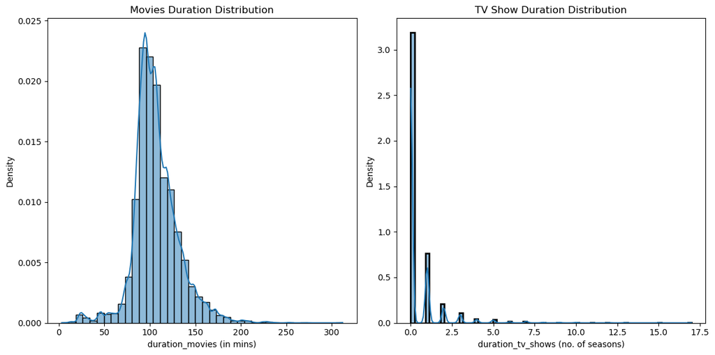

```python
# Create a figure and subplots
fig, (ax1, ax2) = plt.subplots(1, 2, figsize=(12, 6))

# Plotting the Movies duration distribution
movie_duration = df_new.loc[df_new['duration_movies'] > 0, 'duration_movies']
sns.histplot(movie_duration, kde=True, bins=40,
             edgecolor='black', linewidth=1, stat='density', ax=ax1)
ax1.set_title('Movies Duration Distribution')
ax1.set_xlabel('duration_movies (in mins)')

# Plotting the TV Shows duration distribution
tv_dutation = df_new['duration_tv_shows']
sns.histplot(tv_dutation, kde=True, bins=75,
             edgecolor='black', linewidth=2, stat='density', ax=ax2)
ax2.set_title('TV Show Duration Distribution')
ax2.set_xlabel('duration_tv_shows (no. of seasons)')

# Adjust spacing between subplots
fig.tight_layout()

# Display the plot
plt.show()
```

### Observation

> As we can see most of the TV shows have 1 season.

> Most the movies are around the duration of 1h 30mins

### Changing the datatypes for the `date_added` column

```python
df_new.dtypes
```

```
title                object
Actors               object
Director             object
Genre                object
Country              object
show_id              object
type                 object
date_added           object
release_year          int64
rating               object
duration             object
description          object
duration_movies       int64
duration_tv_shows     int64
dtype: object
```

```python
df_new['date_added'].isnull().sum()
```

```
158
```

```python
df['date_added']
```

```
0       September 25, 2021
1       September 24, 2021
2       September 24, 2021
3       September 24, 2021
4       September 24, 2021
               ...
8802     November 20, 2019
8803          July 1, 2019
8804      November 1, 2019
8805      January 11, 2020
8806         March 2, 2019
Name: date_added, Length: 8807, dtype: object
```

```python
def convert_datetime(d):
    if type(d) is not float:
        d = str(d).strip()
    return d
```

```python
df_new['date_added'] = df_new['date_added'].map(convert_datetime)
```

```python
df_new['date_added'].isna().sum()
```

```
158
```

```python
df_new['date_added'] = pd.to_datetime(df_new['date_added'])
```

```python
df_new['date_added'].isna().sum()
```

```
158
```

```python
df_new['date_added_month'] = df_new['date_added'].dt.month
df_new['date_added_year'] = df_new['date_added'].dt.year
df_new['date_added_day'] = df_new['date_added'].dt.day
df_new['date_added_day_name'] = df_new['date_added'].dt.day_name()
df_new['date_added_month_name'] = df_new['date_added'].dt.month_name()
```

```python
df_new.sample(10)
```

|  | title | Actors | Director | Genre | Country | show_id | type | date_added | release_year | rating | duration | description | duration_movies | duration_tv_shows | date_added_month | date_added_year | date_added_day | date_added_day_name | date_added_month_name |
| --- | --- | --- | --- | --- | --- | --- | --- | --- | --- | --- | --- | --- | --- | --- | --- | --- | --- | --- | --- |
| 87083 | The Twins Effect II | Tony Leung Ka Fai | Corey Yuen | International Movies | Hong Kong | s3650 | Movie | 2019-07-21 | 2004 | TV-14 | 106 min | An empress rules over a land where men are sub... | 106 | 0 | 7.0 | 2019.0 | 21.0 | Sunday | July |
| 138619 | American Psycho | Jared Leto | Mary Harron | Cult Movies | United States | s6148 | Movie | 2019-09-01 | 2000 | R | 102 min | With chiseled good looks that belie his insani... | 102 | 0 | 9.0 | 2019.0 | 1.0 | Sunday | September |
| 195717 | The Time Traveler's Wife | Arliss Howard | Robert Schwentke | Sci-Fi & Fantasy | United States | s8533 | Movie | 2019-10-01 | 2009 | PG-13 | 107 min | Due to a genetic disorder, handsome librarian ... | 107 | 0 | 10.0 | 2019.0 | 1.0 | Tuesday | October |
| 6975 | Hit & Run | Sanaa Lathan | Unknown Director | TV Action & Adventure | Israel | s297 | TV Show | 2021-08-06 | 2021 | TV-MA | 1 Season | A man searching for the truth behind his wife'... | 0 | 1 | 8.0 | 2021.0 | 6.0 | Friday | August |
| 111805 | Brain on Fire | Chloë Grace Moretz | Gerard Barrett | Dramas | Canada | s4820 | Movie | 2018-06-22 | 2016 | PG-13 | 89 min | Stricken with seizures, psychosis and memory l... | 89 | 0 | 6.0 | 2018.0 | 22.0 | Friday | June |
| 109928 | Fashion | Mugdha Godse | Madhur Bhandarkar | International Movies | India | s4722 | Movie | 2018-08-02 | 2008 | TV-MA | 158 min | A small-town girl finally realizes her dream o... | 158 | 0 | 8.0 | 2018.0 | 2.0 | Thursday | August |
| 99627 | Watership Down | Craig Parkinson | Noam Murro | International TV Shows | United States | s4263 | TV Show | 2018-12-23 | 2018 | TV-PG | 1 Season | A warren of rabbits battles many threats on th... | 0 | 1 | 12.0 | 2018.0 | 23.0 | Sunday | December |
| 186050 | Taken | Michael Irby | Unknown Director | TV Action & Adventure | France | s8148 | TV Show | 2019-01-12 | 2018 | TV-14 | 2 Seasons | After a personal tragedy upends his life, a hi... | 0 | 2 | 1.0 | 2019.0 | 12.0 | Saturday | January |
| 56459 | Underdogs | Eugenio Derbez | Juan José Campanella | Children & Family Movies | Spain | s2386 | Movie | 2020-06-15 | 2013 | PG | 85 min | When his archenemy returns to settle a score, ... | 85 | 0 | 6.0 | 2020.0 | 15.0 | Monday | June |
| 18297 | Penguin Town | Unknown Actor | Unknown Director | Science & Nature TV | NaN | s711 | TV Show | 2021-06-16 | 2021 | TV-PG | 1 Season | In a picturesque South African town, an eclect... | 0 | 1 | 6.0 | 2021.0 | 16.0 | Wednesday | June |

### Analysis of the `Genre` column

```python
df_new['Genre'].value_counts()
```

```
Dramas                          29775
International Movies            28211
Comedies                        20829
International TV Shows          12845
Action & Adventure              12216
Independent Movies               9834
Children & Family Movies         9771
TV Dramas                        8942
Thrillers                        7107
Romantic Movies                  6412
TV Comedies                      4963
Crime TV Shows                   4733
Horror Movies                    4571
Kids' TV                         4568
Sci-Fi & Fantasy                 4037
Music & Musicals                 3077
Romantic TV Shows                3049
Documentaries                    2407
Anime Series                     2313
TV Action & Adventure            2288
Spanish-Language TV Shows        2126
British TV Shows                 1808
Sports Movies                    1531
Classic Movies                   1434
TV Mysteries                     1281
Korean TV Shows                  1122
Cult Movies                      1077
TV Sci-Fi & Fantasy              1045
Anime Features                   1045
TV Horror                         941
Docuseries                        845
LGBTQ Movies                      838
TV Thrillers                      768
Teen TV Shows                     742
Reality TV                        735
Faith & Spirituality              719
Stand-Up Comedy                   540
Movies                            412
TV Shows                          337
Classic & Cult TV                 272
Stand-Up Comedy & Talk Shows      268
Science & Nature TV               157
Name: Genre, dtype: int64
```

```python
genre_title_count = df_new.groupby('Genre').agg({"title":"nunique"}).sort_values(by=['title'],
                                                 ascending=False).reset_index()
genre_title_count.columns = ['Genre', 'Title']
```

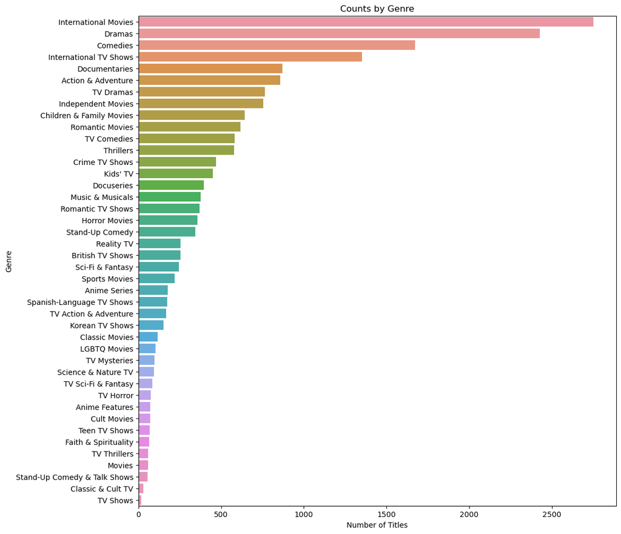

```python
# Plotting a horizontal bar chart
plt.figure(figsize=(30, 12))
sns.barplot(x='Title', y='Genre', data=genre_title_count)

# Set plot title and axis labels
plt.title('Counts by Genre')
plt.xlabel('Number of Titles')
plt.ylabel('Genre')

plt.subplots_adjust(left=0.6)
```

### Analysis based on `type` column (TV show vs Movies)

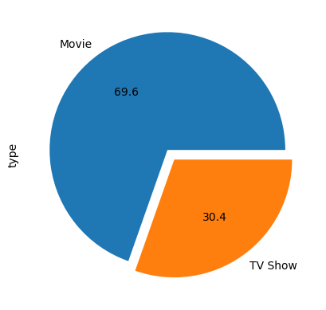

```python
# Check the distribution of TV Show and Movie
df['type'].value_counts(normalize=True).plot(kind='pie', autopct='%.1f', explode=(0.05,0.05));
```

### Observation

> As we can see almost 70% of the content are Movie and 30% are TV shows

```python
df_new
```

|  | title | Actors | Director | Genre | Country | show_id | type | date_added | release_year | rating | duration | description | duration_movies | duration_tv_shows | date_added_month | date_added_year | date_added_day | date_added_day_name | date_added_month_name |
| --- | --- | --- | --- | --- | --- | --- | --- | --- | --- | --- | --- | --- | --- | --- | --- | --- | --- | --- | --- |
| 0 | Dick Johnson Is Dead | Unknown Actor | Kirsten Johnson | Documentaries | United States | s1 | Movie | 2021-09-25 | 2020 | PG-13 | 90 min | As her father nears the end of his life, filmm... | 90 | 0 | 9.0 | 2021.0 | 25.0 | Saturday | September |
| 1 | Blood & Water | Ama Qamata | Unknown Director | International TV Shows | South Africa | s2 | TV Show | 2021-09-24 | 2021 | TV-MA | 2 Seasons | After crossing paths at a party, a Cape Town t... | 0 | 2 | 9.0 | 2021.0 | 24.0 | Friday | September |
| 2 | Blood & Water | Ama Qamata | Unknown Director | TV Dramas | South Africa | s2 | TV Show | 2021-09-24 | 2021 | TV-MA | 2 Seasons | After crossing paths at a party, a Cape Town t... | 0 | 2 | 9.0 | 2021.0 | 24.0 | Friday | September |
| 3 | Blood & Water | Ama Qamata | Unknown Director | TV Mysteries | South Africa | s2 | TV Show | 2021-09-24 | 2021 | TV-MA | 2 Seasons | After crossing paths at a party, a Cape Town t... | 0 | 2 | 9.0 | 2021.0 | 24.0 | Friday | September |
| 4 | Blood & Water | Khosi Ngema | Unknown Director | International TV Shows | South Africa | s2 | TV Show | 2021-09-24 | 2021 | TV-MA | 2 Seasons | After crossing paths at a party, a Cape Town t... | 0 | 2 | 9.0 | 2021.0 | 24.0 | Friday | September |
| ... | ... | ... | ... | ... | ... | ... | ... | ... | ... | ... | ... | ... | ... | ... | ... | ... | ... | ... | ... |
| 201986 | Zubaan | Anita Shabdish | Mozez Singh | International Movies | India | s8807 | Movie | 2019-03-02 | 2015 | TV-14 | 111 min | A scrappy but poor boy worms his way into a ty... | 111 | 0 | 3.0 | 2019.0 | 2.0 | Saturday | March |
| 201987 | Zubaan | Anita Shabdish | Mozez Singh | Music & Musicals | India | s8807 | Movie | 2019-03-02 | 2015 | TV-14 | 111 min | A scrappy but poor boy worms his way into a ty... | 111 | 0 | 3.0 | 2019.0 | 2.0 | Saturday | March |
| 201988 | Zubaan | Chittaranjan Tripathy | Mozez Singh | Dramas | India | s8807 | Movie | 2019-03-02 | 2015 | TV-14 | 111 min | A scrappy but poor boy worms his way into a ty... | 111 | 0 | 3.0 | 2019.0 | 2.0 | Saturday | March |
| 201989 | Zubaan | Chittaranjan Tripathy | Mozez Singh | International Movies | India | s8807 | Movie | 2019-03-02 | 2015 | TV-14 | 111 min | A scrappy but poor boy worms his way into a ty... | 111 | 0 | 3.0 | 2019.0 | 2.0 | Saturday | March |
| 201990 | Zubaan | Chittaranjan Tripathy | Mozez Singh | Music & Musicals | India | s8807 | Movie | 2019-03-02 | 2015 | TV-14 | 111 min | A scrappy but poor boy worms his way into a ty... | 111 | 0 | 3.0 | 2019.0 | 2.0 | Saturday | March |

201991 rows × 19 columns

### Analysis based on `country` column

```python
#number of distinct titles on the basis of country
country_title_count = df_new.groupby('Country').agg({"title":"nunique"}).sort_values(by=['title'],
                                                 ascending=False).reset_index()
country_title_count.columns = ['Country', 'Title']
```

```python
country_title_count[country_title_count.Title > 100]
```

|  | Country | Title |
| --- | --- | --- |
| 0 | United States | 3689 |
| 1 | India | 1046 |
| 2 | United Kingdom | 804 |
| 3 | Canada | 445 |
| 4 | France | 393 |
| 5 | Japan | 318 |
| 6 | Spain | 232 |
| 7 | South Korea | 231 |
| 8 | Germany | 226 |
| 9 | Mexico | 169 |
| 10 | China | 162 |
| 11 | Australia | 160 |
| 12 | Egypt | 117 |
| 13 | Turkey | 113 |
| 14 | Hong Kong | 105 |
| 15 | Nigeria | 103 |

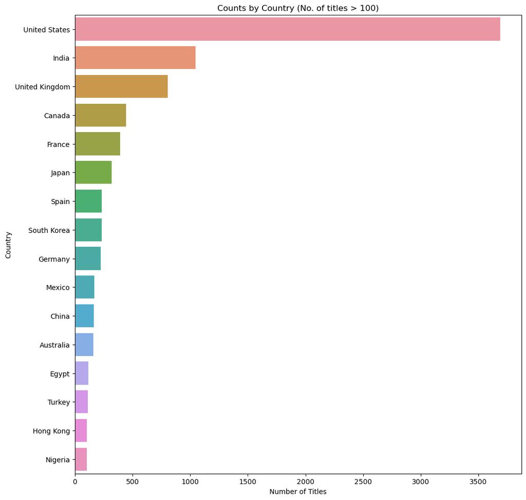

```python
# Plotting a horizontal bar chart
plt.figure(figsize=(30, 12))
sns.barplot(x='Title', y='Country', data=country_title_count[country_title_count.Title > 100])

# Set plot title and axis labels
plt.title('Counts by Country (No. of titles > 100)')
plt.xlabel('Number of Titles')
plt.ylabel('Country')

plt.subplots_adjust(left=0.6)
```

### Observation

> US,India,UK,Canada and France are leading countries in Content Creation on Netflix

```python
#number of distinct titles on the basis of country
country_title_count = df_new.groupby(['Country', 'type']).agg({"title":"nunique"}).sort_values(by=['title'],
                                                 ascending=False).reset_index()
country_title_count.columns = ['Country', 'Type', 'Count']
```

```python
top_10_countries = country_title_count.groupby(['Country']).agg({"Count":"sum"}).sort_values(by=['Count'],
                                                 ascending=False).reset_index()[:10]['Country'].tolist()

top_10 = country_title_count[country_title_count['Country'].isin(top_10_countries)]
```

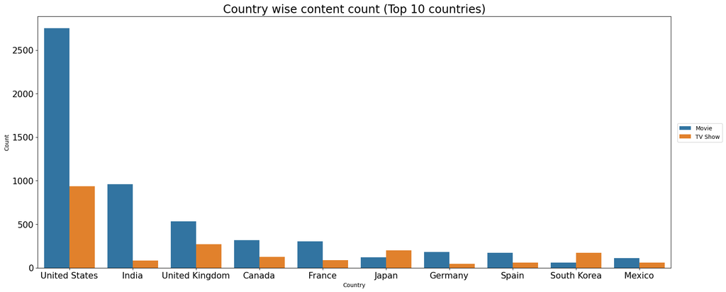

```python
plt.figure(figsize=(20,8))
sns.barplot(x= "Country", y= "Count", data = top_10, hue="Type")
plt.xlabel('Country')
plt.ylabel('Count')

colors = ["#FF7F0F", "#1F77B5"]  # Custom colors for movies and TV shows bars
sns.set_palette(sns.color_palette(colors))

plt.title("Country wise content count (Top 10 countries)",  fontsize=20)
plt.xticks(fontsize=15)
plt.yticks(fontsize=15)

plt.legend(loc=(1.01,0.5))
plt.show()
```

### Observation

> For Japan and South Korea, Netflix should focus more on TV shows as compare to movies For India and US, most of the content are in the form of Movies

### Analysis based on `rating`

```python
#number of distinct titles on the basis of rating
rating_title_count = df_new.groupby('rating').agg({"title":"nunique"}).sort_values(by=['title'],
                                                 ascending=False).reset_index()
rating_title_count.columns = ['rating', 'Title']
```

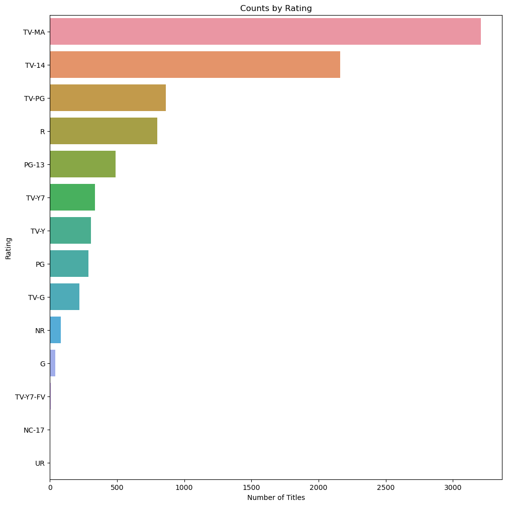

```python
# Plotting a horizontal bar chart
plt.figure(figsize=(30, 12))
sns.barplot(x='Title', y='rating', data=rating_title_count)

# Set plot title and axis labels
plt.title('Counts by Rating')
plt.xlabel('Number of Titles')
plt.ylabel('Rating')

plt.subplots_adjust(left=0.6)
```

### Observation

> As per the above chart, most of the highly rated content on Netflix is intended for Mature Audiences, R Rated, content not intended for audience under 14 and those which require Parental Guidance

### Analysis based on `duration`

### I. For `Movies`

```python
#number of distinct titles on the basis of duration
df_new.groupby(['duration_movies']).agg({"title":"nunique"}).reset_index()

duration_title_count = df_new.groupby(['duration_movies']).agg({"title":"nunique"}).sort_values(by=['title'],
                                                 ascending=False).reset_index()
duration_title_count.columns = ['Duration (in mins)', 'Title']
duration_title_count.drop(0, inplace=True)
```

```python
duration_title_count
```

|  | Duration (in mins) | Title |
| --- | --- | --- |
| 1 | 90 | 152 |
| 2 | 97 | 146 |
| 3 | 93 | 146 |
| 4 | 94 | 146 |
| 5 | 91 | 144 |
| ... | ... | ... |
| 201 | 18 | 1 |
| 202 | 43 | 1 |
| 203 | 178 | 1 |
| 204 | 5 | 1 |
| 205 | 312 | 1 |

205 rows × 2 columns

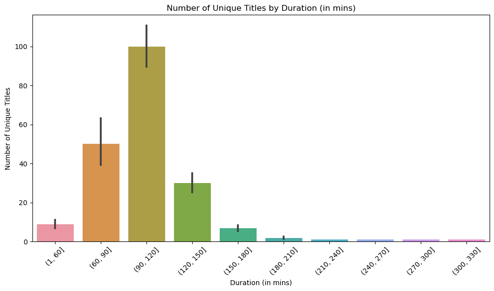

```python
# Set bin ranges
bins = [1] + list(range(60, duration_title_count['Duration (in mins)'].max() + 30, 30))

# Plotting the bar chart with bin size of 30 starting from 1
plt.figure(figsize=(12, 6))
sns.barplot(x=pd.cut(duration_title_count['Duration (in mins)'], bins=bins), y='Title', data=duration_title_count)

# Set plot title and axis labels
plt.title('Number of Unique Titles by Duration (in mins)')
plt.xlabel('Duration (in mins)')
plt.ylabel('Number of Unique Titles')

# Rotate x-axis labels for better readability (if needed)
plt.xticks(rotation=45)

# Display the plot
plt.show()
```

### Observation

> As per the above chart, the most watched movie has a duration from 90mins to 120mins

### II. For `TV Shows`

```python
#number of distinct titles on the basis of duration
df_new.groupby(['duration_tv_shows']).agg({"title":"nunique"}).reset_index()

seasons_title_count = df_new.groupby(['duration_tv_shows']).agg({"title":"nunique"}).sort_values(by=['title'],
                                                 ascending=False).reset_index()
seasons_title_count.columns = ['No. of Seasons', 'Title']
seasons_title_count.drop(0, inplace=True)
```

```python
seasons_title_count
```

|  | No. of Seasons | Title |
| --- | --- | --- |
| 1 | 1 | 1793 |
| 2 | 2 | 425 |
| 3 | 3 | 199 |
| 4 | 4 | 95 |
| 5 | 5 | 65 |
| 6 | 6 | 33 |
| 7 | 7 | 23 |
| 8 | 8 | 17 |
| 9 | 9 | 9 |
| 10 | 10 | 7 |
| 11 | 13 | 3 |
| 12 | 11 | 2 |
| 13 | 12 | 2 |
| 14 | 15 | 2 |
| 15 | 17 | 1 |

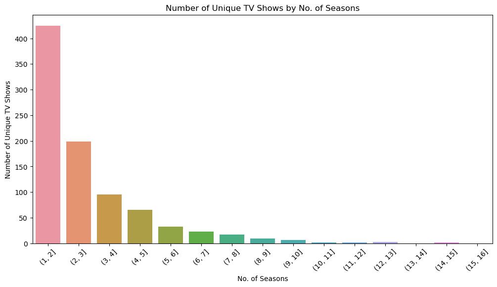

```python
# Set bin ranges
bins = list(range(1, seasons_title_count['No. of Seasons'].max()))

# Plotting the bar chart with bin size of 30 starting from 1
plt.figure(figsize=(12, 6))
sns.barplot(x=pd.cut(seasons_title_count['No. of Seasons'], bins=bins), y='Title', data=seasons_title_count)

# Set plot title and axis labels
plt.title('Number of Unique TV Shows by No. of Seasons')
plt.xlabel('No. of Seasons')
plt.ylabel('Number of Unique TV Shows')

# Rotate x-axis labels for better readability (if needed)
plt.xticks(rotation=45)

# Display the plot
plt.show()
```

```python
bins
```

```
[1, 2, 3, 4, 5, 6, 7, 8, 9, 10, 11, 12, 13, 14, 15, 16]
```

### Observation

> As per the above chart, the most watched TV Show has a 1 or 2 seasons

## Analysis based on `Actor`

```python
#number of distinct titles on the basis of duration
df_new.groupby(['Actors']).agg({"title":"nunique"}).reset_index()

actor_title_count = df_new.groupby(['Actors']).agg({"title":"nunique"}).sort_values(by=['title'],
                                                 ascending=False).reset_index()
actor_title_count.columns = ['Actors', 'Title']
```

```python
actor_title_count
```

|  | Actors | Title |
| --- | --- | --- |
| 0 | Unknown Actor | 825 |
| 1 | Anupam Kher | 43 |
| 2 | Shah Rukh Khan | 35 |
| 3 | Julie Tejwani | 33 |
| 4 | Naseeruddin Shah | 32 |
| ... | ... | ... |
| 36435 | Jamie Lee | 1 |
| 36436 | Jamie Kenna | 1 |
| 36437 | Jamie Kaler | 1 |
| 36438 | Jamie Johnston | 1 |
| 36439 | Ṣọpẹ́ Dìrísù | 1 |

36440 rows × 2 columns

```python
top_20_actors = actor_title_count[actor_title_count['Actors'] != 'Unknown Actor'].head(20)
```

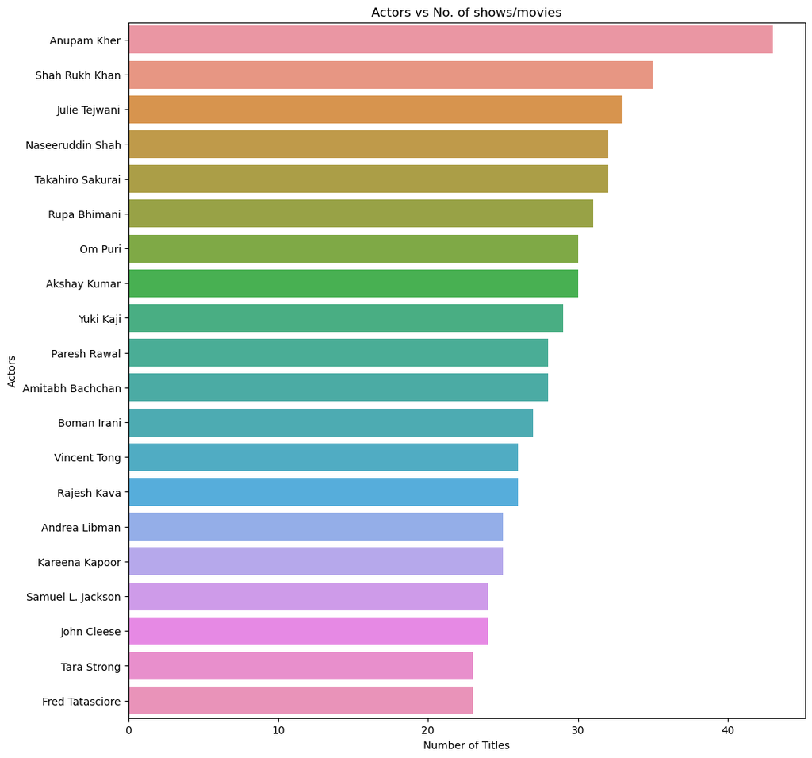

```python
# Plotting a horizontal bar chart
plt.figure(figsize=(30, 12))
sns.barplot(x='Title', y='Actors', data=top_20_actors)

# Set plot title and axis labels
plt.title('Actors vs No. of shows/movies')
plt.xlabel('Number of Titles')
plt.ylabel('Actors')

plt.subplots_adjust(left=0.6)
```

### Observation

> As per the above chart, Anupam Kher,Shah Rukh Khan, Julie Tejwani, Naseeruddin Shah and Takahiro Sakurai occupy the top stop in Most Watched content.

## Analysis based on `Directors`

```python
#number of distinct titles on the basis of duration
df_new.groupby(['Director']).agg({"title":"nunique"}).reset_index()

directors_title_count = df_new.groupby(['Director']).agg({"title":"nunique"}).sort_values(by=['title'],
                                                 ascending=False).reset_index()
directors_title_count.columns = ['Director', 'Title']
```

```python
top_20_director = directors_title_count[directors_title_count['Director'] != 'Unknown Director'].head(20)
```

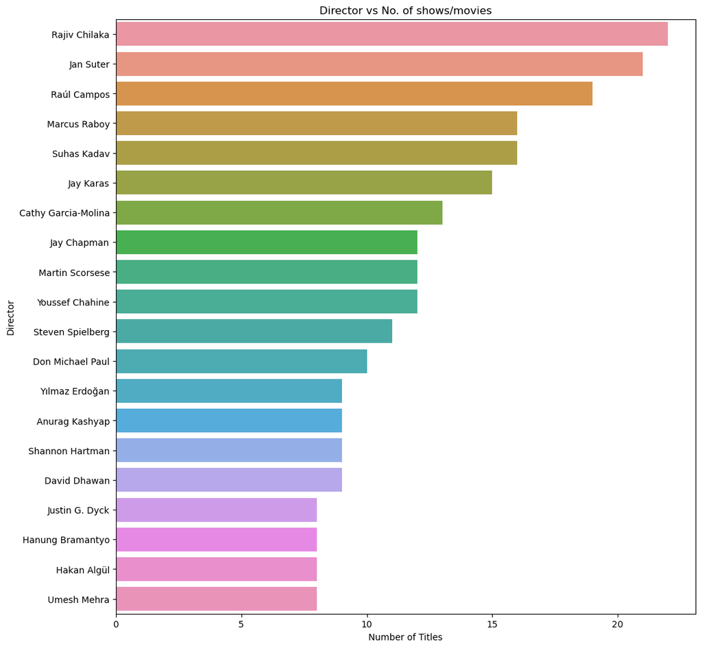

```python
# Plotting a horizontal bar chart
plt.figure(figsize=(30, 12))
sns.barplot(x='Title', y='Director', data=top_20_director)

# Set plot title and axis labels
plt.title('Director vs No. of shows/movies')
plt.xlabel('Number of Titles')
plt.ylabel('Director')

plt.subplots_adjust(left=0.6)
```

### Observation

> As per the above chart, Rajiv Chilaka, Jan Suter and Raul Campos are the most popular directors across Netflix.

```python
df_new.head(2)
```

|  | title | Actors | Director | Genre | Country | show_id | type | date_added | release_year | rating | duration | description | duration_movies | duration_tv_shows | date_added_month | date_added_year | date_added_day | date_added_day_name | date_added_month_name |
| --- | --- | --- | --- | --- | --- | --- | --- | --- | --- | --- | --- | --- | --- | --- | --- | --- | --- | --- | --- |
| 0 | Dick Johnson Is Dead | Unknown Actor | Kirsten Johnson | Documentaries | United States | s1 | Movie | 2021-09-25 | 2020 | PG-13 | 90 min | As her father nears the end of his life, filmm... | 90 | 0 | 9.0 | 2021.0 | 25.0 | Saturday | September |
| 1 | Blood & Water | Ama Qamata | Unknown Director | International TV Shows | South Africa | s2 | TV Show | 2021-09-24 | 2021 | TV-MA | 2 Seasons | After crossing paths at a party, a Cape Town t... | 0 | 2 | 9.0 | 2021.0 | 24.0 | Friday | September |

```python
release_count_by_year = df_new.groupby(['date_added_year']).agg({"title":"nunique"}).sort_values(by=['title'],
                                                 ascending=False).reset_index()

release_count_by_year.columns = ['Year', 'Count']
release_count_by_year.Year = release_count_by_year.Year.astype('int')
```

```python
release_count_by_year
```

|  | Year | Count |
| --- | --- | --- |
| 0 | 2019 | 2016 |
| 1 | 2020 | 1879 |
| 2 | 2018 | 1649 |
| 3 | 2021 | 1498 |
| 4 | 2017 | 1188 |
| 5 | 2016 | 429 |
| 6 | 2015 | 82 |
| 7 | 2014 | 24 |
| 8 | 2011 | 13 |
| 9 | 2013 | 11 |
| 10 | 2012 | 3 |
| 11 | 2008 | 2 |
| 12 | 2009 | 2 |
| 13 | 2010 | 1 |

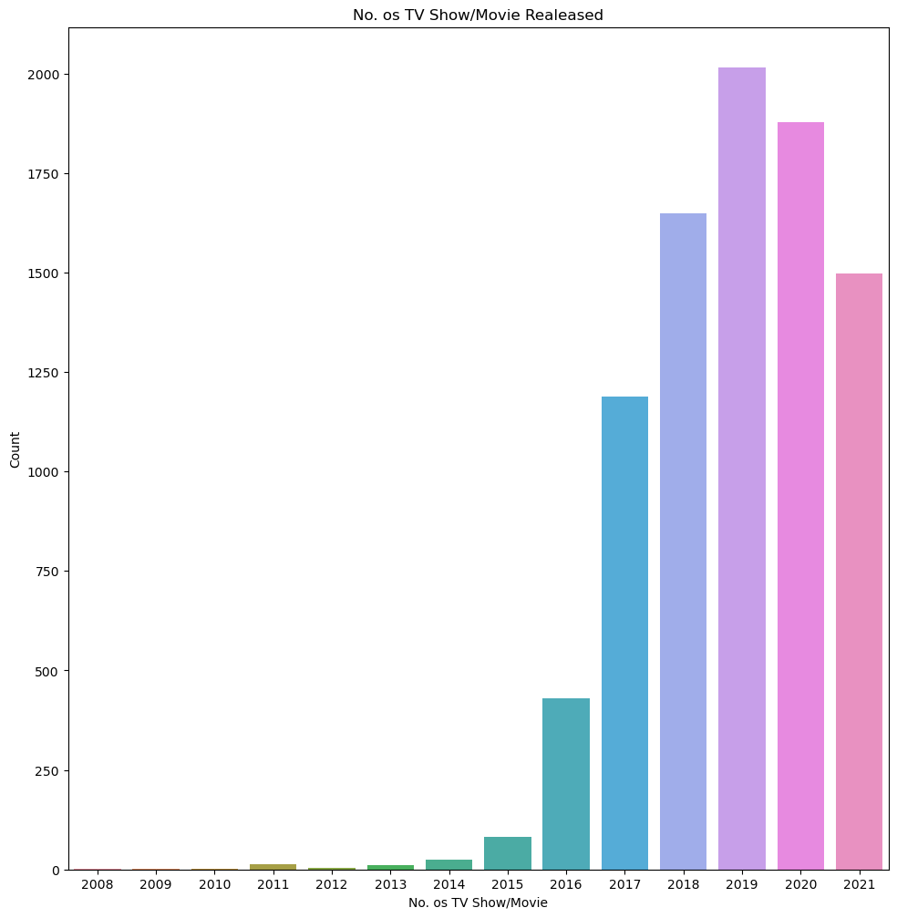

```python
# Plotting a horizontal bar chart
plt.figure(figsize=(30, 12))
sns.barplot(x='Year', y='Count', data=release_count_by_year)

# Set plot title and axis labels
plt.title('No. os TV Show/Movie Realeased')
plt.xlabel('No. os TV Show/Movie')
plt.ylabel('Count')

plt.subplots_adjust(left=0.6)
```

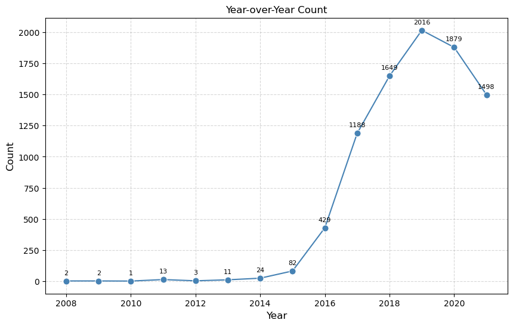

```python
# Plotting the year-over-year count
plt.figure(figsize=(10, 6))
sns.lineplot(x='Year', y='Count', data=release_count_by_year, marker='o', markersize=8, color='steelblue')

# Set plot title and axis labels
plt.title('Year-over-Year Count')
plt.xlabel('Year', fontsize=12)
plt.ylabel('Count', fontsize=12)

# Customize tick labels and gridlines
plt.xticks(fontsize=10)
plt.yticks(fontsize=10)
plt.grid(True, linestyle='--', alpha=0.5)

# Add data labels to each point
for i, count in enumerate(release_count_by_year['Count']):
    plt.text(release_count_by_year['Year'][i], count + 50, str(count), ha='center', fontsize=8, color='black')

# Display the plot
plt.show()
```

### Analysis of TV Shows and Movies over `time`

```python
df_new.head()
```

|  | title | Actors | Director | Genre | Country | show_id | type | date_added | release_year | rating | duration | description | duration_movies | duration_tv_shows | date_added_month | date_added_year | date_added_day | date_added_day_name | date_added_month_name |
| --- | --- | --- | --- | --- | --- | --- | --- | --- | --- | --- | --- | --- | --- | --- | --- | --- | --- | --- | --- |
| 0 | Dick Johnson Is Dead | Unknown Actor | Kirsten Johnson | Documentaries | United States | s1 | Movie | 2021-09-25 | 2020 | PG-13 | 90 min | As her father nears the end of his life, filmm... | 90 | 0 | 9.0 | 2021.0 | 25.0 | Saturday | September |
| 1 | Blood & Water | Ama Qamata | Unknown Director | International TV Shows | South Africa | s2 | TV Show | 2021-09-24 | 2021 | TV-MA | 2 Seasons | After crossing paths at a party, a Cape Town t... | 0 | 2 | 9.0 | 2021.0 | 24.0 | Friday | September |
| 2 | Blood & Water | Ama Qamata | Unknown Director | TV Dramas | South Africa | s2 | TV Show | 2021-09-24 | 2021 | TV-MA | 2 Seasons | After crossing paths at a party, a Cape Town t... | 0 | 2 | 9.0 | 2021.0 | 24.0 | Friday | September |
| 3 | Blood & Water | Ama Qamata | Unknown Director | TV Mysteries | South Africa | s2 | TV Show | 2021-09-24 | 2021 | TV-MA | 2 Seasons | After crossing paths at a party, a Cape Town t... | 0 | 2 | 9.0 | 2021.0 | 24.0 | Friday | September |
| 4 | Blood & Water | Khosi Ngema | Unknown Director | International TV Shows | South Africa | s2 | TV Show | 2021-09-24 | 2021 | TV-MA | 2 Seasons | After crossing paths at a party, a Cape Town t... | 0 | 2 | 9.0 | 2021.0 | 24.0 | Friday | September |

```python
df_datetime_month = df_new.groupby(['type', 'date_added_month', 'date_added_month_name']).agg({"title":"nunique"}).reset_index()
df_datetime_month
```

|  | type | date_added_month | date_added_month_name | title |
| --- | --- | --- | --- | --- |
| 0 | Movie | 1.0 | January | 546 |
| 1 | Movie | 2.0 | February | 382 |
| 2 | Movie | 3.0 | March | 529 |
| 3 | Movie | 4.0 | April | 550 |
| 4 | Movie | 5.0 | May | 439 |
| 5 | Movie | 6.0 | June | 492 |
| 6 | Movie | 7.0 | July | 565 |
| 7 | Movie | 8.0 | August | 519 |
| 8 | Movie | 9.0 | September | 519 |
| 9 | Movie | 10.0 | October | 545 |
| 10 | Movie | 11.0 | November | 498 |
| 11 | Movie | 12.0 | December | 547 |
| 12 | TV Show | 1.0 | January | 192 |
| 13 | TV Show | 2.0 | February | 181 |
| 14 | TV Show | 3.0 | March | 213 |
| 15 | TV Show | 4.0 | April | 214 |
| 16 | TV Show | 5.0 | May | 193 |
| 17 | TV Show | 6.0 | June | 236 |
| 18 | TV Show | 7.0 | July | 262 |
| 19 | TV Show | 8.0 | August | 236 |
| 20 | TV Show | 9.0 | September | 251 |
| 21 | TV Show | 10.0 | October | 215 |
| 22 | TV Show | 11.0 | November | 207 |
| 23 | TV Show | 12.0 | December | 266 |

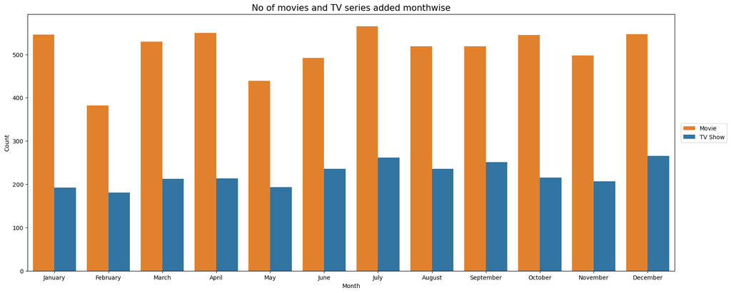

```python
plt.figure(figsize=(20,8))
sns.barplot(x= "date_added_month_name", y= "title", data = df_datetime_month, hue="type")
plt.xlabel('Month')
plt.ylabel('Count')

colors = ["#FF7F0F", "#1F77B5"]  # Custom colors for movies and TV shows bars
sns.set_palette(sns.color_palette(colors))

plt.title("No of movies and TV series added monthwise",  fontsize=15)
plt.legend(loc=(1.01,0.5))
plt.show()
```

### Observation

> July and December are the months when most content both for Movies and TV Shows, thats mostly beacuse of Vacation Time (schools/colleges), or may be beacuse of Summer/Winter break

> No of movies added per month is greater then no of TV shows added per month.

```python
df_datetime_year = df_new.groupby(['type', 'date_added_year']).agg({"title":"nunique"}).reset_index()
df_datetime_year['date_added_year'] = df_datetime_year['date_added_year'].astype('int')
df_datetime_year_last_7years = df_datetime_year[df_datetime_year['date_added_year'] > 2013]
df_datetime_year_last_7years
```

|  | type | date_added_year | title |
| --- | --- | --- | --- |
| 6 | Movie | 2014 | 19 |
| 7 | Movie | 2015 | 56 |
| 8 | Movie | 2016 | 253 |
| 9 | Movie | 2017 | 839 |
| 10 | Movie | 2018 | 1237 |
| 11 | Movie | 2019 | 1424 |
| 12 | Movie | 2020 | 1284 |
| 13 | Movie | 2021 | 993 |
| 16 | TV Show | 2014 | 5 |
| 17 | TV Show | 2015 | 26 |
| 18 | TV Show | 2016 | 176 |
| 19 | TV Show | 2017 | 349 |
| 20 | TV Show | 2018 | 412 |
| 21 | TV Show | 2019 | 592 |
| 22 | TV Show | 2020 | 595 |
| 23 | TV Show | 2021 | 505 |

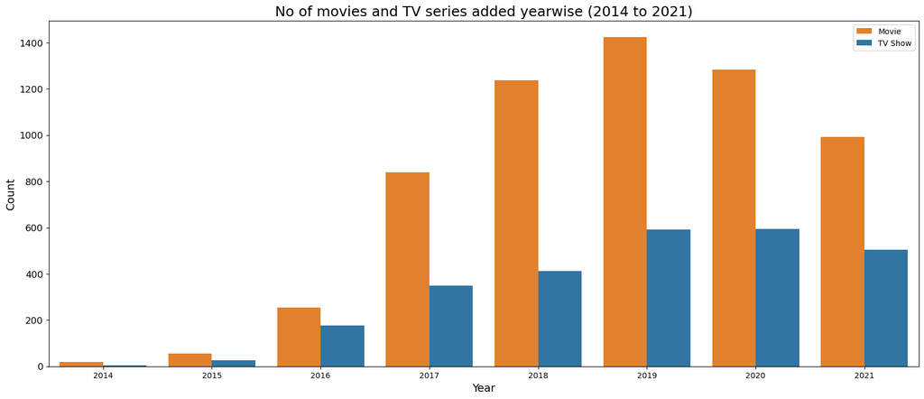

```python
plt.figure(figsize=(20,8))
sns.barplot(x= "date_added_year", y= "title", data = df_datetime_year_last_7years, hue="type")
plt.xlabel('Year', fontsize=14)
plt.ylabel('Count', fontsize=14)
plt.yticks(fontsize=12)

colors = ["#FF7F0F", "#1F77B5"]  # Custom colors for movies and TV shows bars
sns.set_palette(sns.color_palette(colors))

plt.title("No of movies and TV series added yearwise (2014 to 2021)",  fontsize=18)

plt.legend()
plt.show()
```

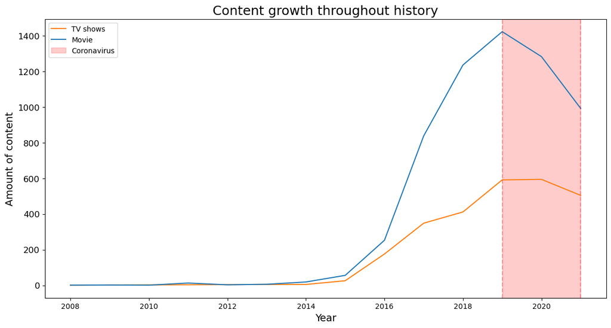

```python
TVshows = df_datetime_year[df_datetime_year['type'] == 'TV Show']
Movie = df_datetime_year[df_datetime_year['type'] == 'Movie']

TVshows_progress = TVshows['date_added_year']
Movie_progress = Movie['date_added_year']

plt.figure(figsize=(14, 7))

plt.plot(TVshows_progress, TVshows.title, label='TV shows')
plt.plot(Movie_progress, Movie.title, label='Movie')


plt.axvline(2019, alpha=0.3, linestyle='--', color='r')
plt.axvline(2021, alpha=0.3, linestyle='--', color='r')
plt.axvspan(2019, 2021, alpha=0.2, color='r', label='Coronavirus')

# plt.xticks(list(range(1925, 2026, 5)), fontsize=12)
plt.title('Content growth throughout history', fontsize=18)
plt.xlabel('Year', fontsize=14)
plt.ylabel('Amount of content', fontsize=14)
plt.yticks(fontsize=12)
plt.legend()
plt.show()
```

### Observation

> The no. of content on Netflix increased drastically from 2015 obwards

> We can also see that after 2019, the no. of contents decreased, mostly due to COVID pandemic.

```python
df_new.head(5)
```

|  | title | Actors | Director | Genre | Country | show_id | type | date_added | release_year | rating | duration | description | duration_movies | duration_tv_shows | date_added_month | date_added_year | date_added_day | date_added_day_name | date_added_month_name |
| --- | --- | --- | --- | --- | --- | --- | --- | --- | --- | --- | --- | --- | --- | --- | --- | --- | --- | --- | --- |
| 0 | Dick Johnson Is Dead | Unknown Actor | Kirsten Johnson | Documentaries | United States | s1 | Movie | 2021-09-25 | 2020 | PG-13 | 90 min | As her father nears the end of his life, filmm... | 90 | 0 | 9.0 | 2021.0 | 25.0 | Saturday | September |
| 1 | Blood & Water | Ama Qamata | Unknown Director | International TV Shows | South Africa | s2 | TV Show | 2021-09-24 | 2021 | TV-MA | 2 Seasons | After crossing paths at a party, a Cape Town t... | 0 | 2 | 9.0 | 2021.0 | 24.0 | Friday | September |
| 2 | Blood & Water | Ama Qamata | Unknown Director | TV Dramas | South Africa | s2 | TV Show | 2021-09-24 | 2021 | TV-MA | 2 Seasons | After crossing paths at a party, a Cape Town t... | 0 | 2 | 9.0 | 2021.0 | 24.0 | Friday | September |
| 3 | Blood & Water | Ama Qamata | Unknown Director | TV Mysteries | South Africa | s2 | TV Show | 2021-09-24 | 2021 | TV-MA | 2 Seasons | After crossing paths at a party, a Cape Town t... | 0 | 2 | 9.0 | 2021.0 | 24.0 | Friday | September |
| 4 | Blood & Water | Khosi Ngema | Unknown Director | International TV Shows | South Africa | s2 | TV Show | 2021-09-24 | 2021 | TV-MA | 2 Seasons | After crossing paths at a party, a Cape Town t... | 0 | 2 | 9.0 | 2021.0 | 24.0 | Friday | September |

```python
df_datetime_day = df_new.groupby(['type', 'date_added_day_name']).agg({"title":"nunique"}).reset_index()

order = ["Monday", "Tuesday", "Wednesday", "Thursday", "Friday", "Saturday", "Sunday"]
df_datetime_day['date_added_day_name'] = pd.Categorical(df_datetime_day['date_added_day_name'], categories=order, ordered=True)
df_datetime_day = df_datetime_day.sort_values(['type', 'date_added_day_name'])

df_datetime_day
```

|  | type | date_added_day_name | title |
| --- | --- | --- | --- |
| 1 | Movie | Monday | 628 |
| 5 | Movie | Tuesday | 852 |
| 6 | Movie | Wednesday | 906 |
| 4 | Movie | Thursday | 1053 |
| 0 | Movie | Friday | 1566 |
| 2 | Movie | Saturday | 557 |
| 3 | Movie | Sunday | 569 |
| 8 | TV Show | Monday | 223 |
| 12 | TV Show | Tuesday | 345 |
| 13 | TV Show | Wednesday | 382 |
| 11 | TV Show | Thursday | 343 |
| 7 | TV Show | Friday | 932 |
| 9 | TV Show | Saturday | 259 |
| 10 | TV Show | Sunday | 182 |

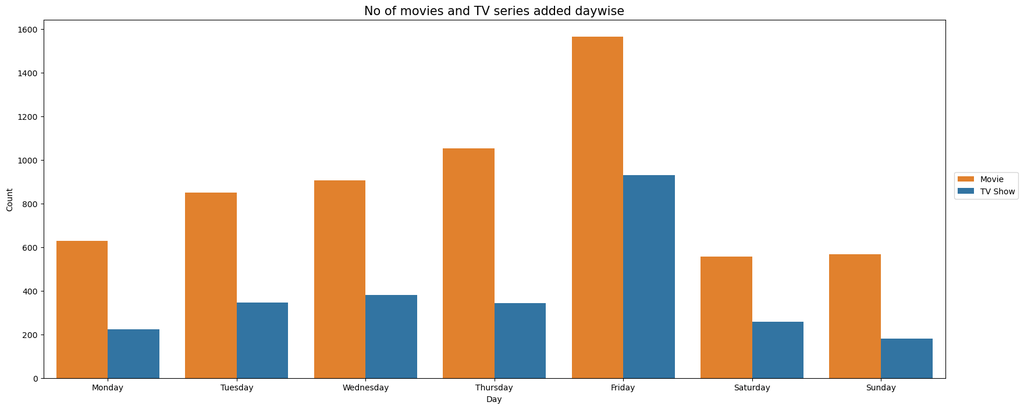

```python
plt.figure(figsize=(20,8))
sns.barplot(x= "date_added_day_name", y= "title", data = df_datetime_day, hue="type")
plt.xlabel('Day')
plt.ylabel('Count')

colors = ["#FF7F0F", "#1F77B5"]  # Custom colors for movies and TV shows bars
sns.set_palette(sns.color_palette(colors))

plt.title("No of movies and TV series added daywise",  fontsize=15)
plt.legend(loc=(1.01,0.5))
plt.show()
```

### Observation

> Number of content added on Netflix on "Friday" is the max. followed by Thursday as weekend appraches after these days. New content on Monday, Tuesday are lower mostly beacuse its the start of the week, and we expect people would be more engrossed with work/school/college

### Analysis of TV Shows and Movies over `Genre`

```python
df_new.head()
```

|  | title | Actors | Director | Genre | Country | show_id | type | date_added | release_year | rating | duration | description | duration_movies | duration_tv_shows | date_added_month | date_added_year | date_added_day | date_added_day_name | date_added_month_name |
| --- | --- | --- | --- | --- | --- | --- | --- | --- | --- | --- | --- | --- | --- | --- | --- | --- | --- | --- | --- |
| 0 | Dick Johnson Is Dead | Unknown Actor | Kirsten Johnson | Documentaries | United States | s1 | Movie | 2021-09-25 | 2020 | PG-13 | 90 min | As her father nears the end of his life, filmm... | 90 | 0 | 9.0 | 2021.0 | 25.0 | Saturday | September |
| 1 | Blood & Water | Ama Qamata | Unknown Director | International TV Shows | South Africa | s2 | TV Show | 2021-09-24 | 2021 | TV-MA | 2 Seasons | After crossing paths at a party, a Cape Town t... | 0 | 2 | 9.0 | 2021.0 | 24.0 | Friday | September |
| 2 | Blood & Water | Ama Qamata | Unknown Director | TV Dramas | South Africa | s2 | TV Show | 2021-09-24 | 2021 | TV-MA | 2 Seasons | After crossing paths at a party, a Cape Town t... | 0 | 2 | 9.0 | 2021.0 | 24.0 | Friday | September |
| 3 | Blood & Water | Ama Qamata | Unknown Director | TV Mysteries | South Africa | s2 | TV Show | 2021-09-24 | 2021 | TV-MA | 2 Seasons | After crossing paths at a party, a Cape Town t... | 0 | 2 | 9.0 | 2021.0 | 24.0 | Friday | September |
| 4 | Blood & Water | Khosi Ngema | Unknown Director | International TV Shows | South Africa | s2 | TV Show | 2021-09-24 | 2021 | TV-MA | 2 Seasons | After crossing paths at a party, a Cape Town t... | 0 | 2 | 9.0 | 2021.0 | 24.0 | Friday | September |

```python
#number of distinct titles on the basis of duration
genre_title_count = df_new.groupby(['Genre']).agg({"title":"nunique"}).sort_values(by=['title'],
                                                 ascending=False).reset_index()
genre_title_count.columns = ['Genre', 'Title']
```

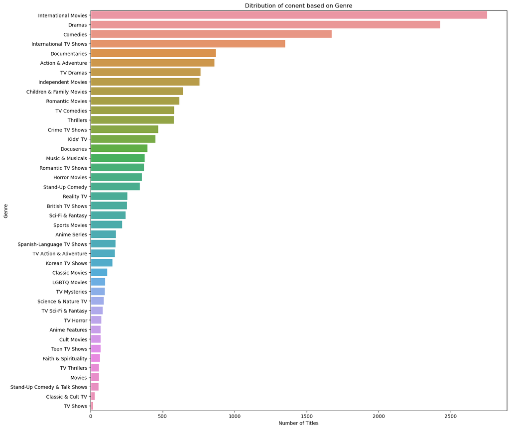

```python
# Plotting a horizontal bar chart
plt.figure(figsize=(40, 15))
sns.barplot(x='Title', y='Genre', data=genre_title_count)

# Set plot title and axis labels
plt.title('Ditribution of conent based on Genre')
plt.xlabel('Number of Titles')
plt.ylabel('Genre')

plt.subplots_adjust(left=0.6)
```

### Observation

> Most appearing category in netflix movies and TV shows are:
> - International Movies
> - Dramas
> - Comedies
> - International TV show
> - Documentaries

### Non-Graphical Analysis (Top Actors/Directors in different countries)

```python
df_new.head()
```

|  | title | Actors | Director | Genre | Country | show_id | type | date_added | release_year | rating | duration | description | duration_movies | duration_tv_shows | date_added_month | date_added_year | date_added_day | date_added_day_name | date_added_month_name |
| --- | --- | --- | --- | --- | --- | --- | --- | --- | --- | --- | --- | --- | --- | --- | --- | --- | --- | --- | --- |
| 0 | Dick Johnson Is Dead | Unknown Actor | Kirsten Johnson | Documentaries | United States | s1 | Movie | 2021-09-25 | 2020 | PG-13 | 90 min | As her father nears the end of his life, filmm... | 90 | 0 | 9.0 | 2021.0 | 25.0 | Saturday | September |
| 1 | Blood & Water | Ama Qamata | Unknown Director | International TV Shows | South Africa | s2 | TV Show | 2021-09-24 | 2021 | TV-MA | 2 Seasons | After crossing paths at a party, a Cape Town t... | 0 | 2 | 9.0 | 2021.0 | 24.0 | Friday | September |
| 2 | Blood & Water | Ama Qamata | Unknown Director | TV Dramas | South Africa | s2 | TV Show | 2021-09-24 | 2021 | TV-MA | 2 Seasons | After crossing paths at a party, a Cape Town t... | 0 | 2 | 9.0 | 2021.0 | 24.0 | Friday | September |
| 3 | Blood & Water | Ama Qamata | Unknown Director | TV Mysteries | South Africa | s2 | TV Show | 2021-09-24 | 2021 | TV-MA | 2 Seasons | After crossing paths at a party, a Cape Town t... | 0 | 2 | 9.0 | 2021.0 | 24.0 | Friday | September |
| 4 | Blood & Water | Khosi Ngema | Unknown Director | International TV Shows | South Africa | s2 | TV Show | 2021-09-24 | 2021 | TV-MA | 2 Seasons | After crossing paths at a party, a Cape Town t... | 0 | 2 | 9.0 | 2021.0 | 24.0 | Friday | September |

```python
dir_country = df_new[df_new['Director'] != 'Unknown Director']
dir_country_title_count = dir_country.groupby(['Country', 'Director']).agg({"title":"nunique"}).sort_values(by=['title', 'Country'],
                                                 ascending=False).reset_index()
```

```python
# all_countries = dir_country_title_count['Country'].unique()

# for country in all_countries:
#     print("*********************************************************")
#     print(f"Top Directors from the country : {country}")
#     print("*********************************************************")
#     top_dir = dir_country_title_count[dir_country_title_count['Country'] == country]

#     print(top_dir.iloc[0:2, [1,2]].to_string(index=False))
#     print()
```

```python
countries = ['India', 'United States', 'United Kingdom', 'France']

for country in countries:
    print("*********************************************************")
    print(f"Top Directors from the country : {country}")
    print("*********************************************************")
    top_dir = dir_country_title_count[dir_country_title_count['Country'] == country]

    print(top_dir.iloc[0:2, [1,2]].to_string(index=False))
    print()
```

```
Top Directors from the country : India
      Director  title
Anurag Kashyap      9
  David Dhawan      9

Top Directors from the country : United States
    Director  title
   Jay Karas     15
Marcus Raboy     15

Top Directors from the country : United Kingdom
           Director  title
Alastair Fothergill      4
   Edward Cotterill      4

Top Directors from the country : France
       Director  title
 Thierry Donard      5
Youssef Chahine      4
```

### Observation

> Anurag Kashyap and David Dhawan are the most famous directors for Inida.

> Jay Karas and Marcus Raboyare are the most famous directors in United States.

> Alastair Fothergill and Edward Cotterill are the most famous directors in UK.

```python
actor_country = df_new[df_new['Actors'] != 'Unknown Actor']
actor_country_title_count = actor_country.groupby(['Country', 'Actors']).agg({"title":"nunique"}).sort_values(by=['title', 'Country'],
                                                 ascending=False).reset_index()
```

```python
actor_country_title_count
```

|  | Country | Actors | title |
| --- | --- | --- | --- |
| 0 | India | Anupam Kher | 40 |
| 1 | India | Shah Rukh Khan | 34 |
| 2 | India | Naseeruddin Shah | 31 |
| 3 | Japan | Takahiro Sakurai | 29 |
| 4 | India | Akshay Kumar | 29 |
| ... | ... | ... | ... |
| 50884 |  | Nisreen Faour | 1 |
| 50885 |  | Son Suk-ku | 1 |
| 50886 |  | Souad Massi | 1 |
| 50887 |  | Suhail Haddad | 1 |
| 50888 |  | Walid Abdul Salam | 1 |

50889 rows × 3 columns

```python
# all_countries = actor_country_title_count['Country'].unique()

# for country in all_countries:
#     print("*********************************************************")
#     print(f"Top Actors from the country : {country}")
#     print("*********************************************************")
#     top_dir = actor_country_title_count[actor_country_title_count['Country'] == country]

#     print(top_dir.iloc[0:2, [1,2]].to_string(index=False))
#     print()
```

```python
countries = ['India', 'United States', 'United Kingdom', 'France']

for country in countries:
    print("*********************************************************")
    print(f"Top Actors from the country : {country}")
    print("*********************************************************")
    top_dir = actor_country_title_count[actor_country_title_count['Country'] == country]

    print(top_dir.iloc[0:2, [1,2]].to_string(index=False))
    print()
```

```
Top Actors from the country : India
        Actors  title
   Anupam Kher     40
Shah Rukh Khan     34

Top Actors from the country : United States
           Actors  title
Samuel L. Jackson     22
      Tara Strong     22

Top Actors from the country : United Kingdom
            Actors  title
David Attenborough     17
       John Cleese     16

Top Actors from the country : France
        Actors  title
Benoît Magimel      5
Wille Lindberg      5
```

### Observation

> Anupam Kher and Shah Rukh Khan are the most famous actors for Inida.

> Samuel L. Jackson and Tara Strong are the most famous actors for USA.

> David Attenboroug and John Cleese are the most famous actors for UK.

```python
top_20_actors = actor_country_title_count.sort_values('title', ascending=False)[:20]

print("**********************************************")
print("        Top 20 actors across the globe")
print("**********************************************")

print(top_20_actors)
print("**********************************************")
```

```
        Top 20 actors across the globe
          Country             Actors  title
0           India        Anupam Kher     40
1           India     Shah Rukh Khan     34
2           India   Naseeruddin Shah     31
3           Japan   Takahiro Sakurai     29
4           India       Akshay Kumar     29
5           India            Om Puri     29
6           Japan          Yuki Kaji     28
7           India   Amitabh Bachchan     28
8           India       Paresh Rawal     28
9           India        Boman Irani     27
10          India     Kareena Kapoor     25
11  United States  Samuel L. Jackson     22
12  United States        Tara Strong     22
13          Japan        Daisuke Ono     22
14  United States    Fred Tatasciore     21
15          India         Ajay Devgn     21
17          India        Salman Khan     20
16  United States       Adam Sandler     20
18  United States       James Franco     19
19  United States       Nicolas Cage     19
```

### Heatmaps (`Country` v/s `Ratings`)

```python
#number of distinct titles on the basis of rating
rating_country_title_count = df_new.groupby(['Country', 'rating']).agg({"title":"nunique"}).sort_values(by=['title'],
                                                 ascending=False).reset_index()
rating_country_title_count.columns = ['Country', 'Rating', 'Count']
```

```python
rating_country_title_count
```

|  | Country | Rating | Count |
| --- | --- | --- | --- |
| 0 | United States | TV-MA | 1100 |
| 1 | United States | R | 660 |
| 2 | India | TV-14 | 572 |
| 3 | United States | TV-14 | 497 |
| 4 | United States | PG-13 | 433 |
| ... | ... | ... | ... |
| 511 | Malawi | TV-PG | 1 |
| 512 | Malaysia | TV-Y | 1 |
| 513 | Malta | PG-13 | 1 |
| 514 | Malta | R | 1 |
| 515 | Zimbabwe | TV-MA | 1 |

516 rows × 3 columns

[figure not shown]

```python
to_10_countries_names = rating_country_title_count.groupby('Country').agg({'Count': 'sum'}).sort_values(by=['Count'],
                                                    ascending=False).reset_index().loc[:11, 'Country']
to_10_countries = rating_country_title_count[rating_country_title_count['Country'].isin(to_10_countries_names)]
heatmap_data = to_10_countries.pivot(index='Country', columns='Rating', values='Count')
heatmap_data = heatmap_data.fillna(0).astype('int')
plt.figure(figsize=(20, 15))

sns.heatmap(heatmap_data, annot=True, cmap="Blues", fmt = "d")
plt.title('Rating Count by Country (top 10)', fontsize=25)
plt.xlabel('Rating', fontsize=18)
plt.ylabel('Country', fontsize=18)
plt.yticks(fontsize=15)


plt.show()
```

### Observation

> India and United States are having large content in TV-14 category

> United Kingdom and United States are having large content in R category

> Very less no. of TV shows which are meant for Children (TV-Y and TV-Y7)

### Heatmaps (`Country` v/s `Genre`)

```python
#number of distinct titles on the basis of rating
genre_country_title_count = df_new.groupby(['Country', 'Genre']).agg({"title":"nunique"}).sort_values(by=['title'],
                                                 ascending=False).reset_index()
genre_country_title_count.columns = ['Country', 'Genre', 'Count']
```

```python
genre_country_title_count
```

|  | Country | Genre | Count |
| --- | --- | --- | --- |
| 0 | India | International Movies | 864 |
| 1 | United States | Dramas | 835 |
| 2 | United States | Comedies | 680 |
| 3 | India | Dramas | 662 |
| 4 | United States | Documentaries | 511 |
| ... | ... | ... | ... |
| 1417 | Mauritius | International TV Shows | 1 |
| 1418 | Mauritius | TV Dramas | 1 |
| 1419 | Mexico | Classic Movies | 1 |
| 1420 | Mexico | Faith & Spirituality | 1 |
| 1421 | Zimbabwe | Romantic Movies | 1 |

1422 rows × 3 columns

[figure not shown]

```python
top_10_countries_names = genre_country_title_count.groupby('Country').agg({'Count': 'sum'}).sort_values(by=['Count'],
                                                    ascending=False).reset_index().loc[:11, 'Country']

top_10_genre_names = genre_country_title_count.groupby('Genre').agg({'Count': 'sum'}).sort_values(by=['Count'],
                                                    ascending=False).reset_index().loc[:11, 'Genre']


top_10_genre = genre_country_title_count[genre_country_title_count['Genre'].isin(top_10_genre_names)]
top_10_countries = top_10_genre[top_10_genre['Country'].isin(top_10_countries_names)]

heatmap_data = top_10_countries.pivot(index='Country', columns='Genre', values='Count')
heatmap_data = heatmap_data.fillna(0).astype('int')
plt.figure(figsize=(20, 15))

sns.heatmap(heatmap_data, annot=True, cmap="Greens", fmt = "d")
plt.title('Genre Count by Country (top 10)', fontsize=25)
plt.xlabel('Country', fontsize=18)
plt.ylabel('Genre', fontsize=18)
plt.yticks(fontsize=18)
plt.xticks(fontsize=18)


plt.show()
```

### Observation

> For United States , Netflix should add more content of genre Dramas and Comedy.

> For India, Netflix should add more content of genre International movies , Dramas and Comedies.